# Introduction to the BTWAR Package

Carlos Brás-Geraldes

J. Leonel Rocha

2026-03-06

# Introduction

The **BTWAR** package implements the Butterworth-Induced Autoregressive (BTW-AR) model introduced in Bras-Geraldes, Rocha, and Martins (2026). The method derives autoregressive (AR) coefficients directly from analog Butterworth filter prototypes mapped into the discrete-time domain via the Matched Z-Transform (MZT).

The central idea is to exploit the well-understood frequency-selectivity properties of Butterworth filters, namely a maximally flat magnitude response, monotonic roll-off, and a single tunable cutoff frequency, and translate them into a structured family of AR models. This establishes a principled connection between **frequency-domain filter design** and **time-domain autoregressive modeling**.

Unlike conventional AR modeling, where coefficients are estimated freely from data, the BTW-AR model fixes the AR structure through two physically meaningful hyperparameters: the filter order $N$ and the stopband attenuation $A$. Only a single scalar gain $\alpha$ is estimated from the data. This parsimony has an important practical consequence: the fitted model admits a transparent frequency-domain interpretation that purely data-driven approaches cannot provide.

The key advantages of the BTW-AR framework are:

- AR coefficients are fully determined by two interpretable parameters: filter order $N$ and stopband attenuation $A$;
- The cutoff frequency $f_c$ is derived analytically from $(N, A)$, providing a direct spectral interpretation of the selected model;
- Model order selection is performed via nested rolling-origin cross-validation, avoiding look-ahead bias;
- Scaling estimation supports three methods: least squares (LS), least absolute deviations (LAD), and Huber M-estimation, providing robustness options for non-Gaussian series.

# Methodology

## Butterworth Filter Prototype

An $N$-th order analog Butterworth lowpass filter with arbitrary gain $H_0$ has transfer function

$$H_a(s) = \frac{H_0}{\prod_{k=1}^{N}(s - s_k)},$$

where the poles $s_k$ are located on a semicircle of radius $\Omega_c$ in the left half of the $s$-plane,

$$s_k = \Omega_c \, e^{\,j\left(\frac{\pi}{2} +
\frac{(2k-1)\pi}{2N}\right)},
\quad k = 1, \ldots, N,$$

ensuring stability.

In this framework, $H_0 = 1$ is adopted to preserve the spectral shape and establish a direct correspondence with the AR model in the $z$-domain.

## Matched Z-Transform

The MZT maps each analog pole $s_k$ to a discrete-time pole $z_k = e^{s_k T}$, where $T = 1/f_s$ is the sampling period. Since the Butterworth prototype is an all-pole filter with $H_0 = 1$, the system has no finite zeros, and the discrete-time transfer function reduces to

$$H(z) = \frac{1}{\prod_{k=1}^{N}\left(1 - z_k z^{-1}\right)},
\quad z_k = e^{s_k T},$$

which preserves the all-pole structure required by an AR model. Expanding the denominator polynomial using Viète’s formulas yields

$$\prod_{k=1}^{N}\left(1 - z_k z^{-1}\right)
= 1 + a_1 z^{-1} + a_2 z^{-2} + \cdots + a_N z^{-N},$$

and the AR coefficients are obtained directly as $\phi_i = -a_i$, so that the transfer function matches the standard AR form

$$H(z) = \frac{1}{1 - \phi_1 z^{-1} - \cdots - \phi_N z^{-N}}.$$

## Correspondence Between Filter Order and AR Order

The following result, established in Bras-Geraldes, Rocha, and Martins (2026), formalises the equivalence between the number of digital poles and the number of lags in the autoregressive model.

**Proposition.**

*Let $H(z)$ be the transfer function of an autoregressive model $y(n)$ of order $p$. Then $H(z)$ has precisely $p = N$ lags, where $N$ is the number of discrete-time poles $z_k = e^{s_k T}$, $k = 1, \ldots, N$. In addition, the AR coefficients satisfy $\phi_i = -a_i$, where the coefficients $a_i$ are given by Viète’s formulas, for $i = 1, \ldots, p$.*

This Proposition has a direct practical consequence: the Butterworth filter order $N$ simultaneously determines the autoregressive model order $p$. This property provides a direct interpretability link between spectral design parameters and the temporal dynamics of the resulting stochastic process. In the example that follows, the partial autocorrelation function (PACF) is used as a heuristic to fix $p = 3$, which immediately sets $N = 3$ for the Butterworth design.

## The Butterworth-Induced Autoregressive Model

The principal theoretical result of Bras-Geraldes, Rocha, and Martins (2026) is the following theorem, which formally defines the BTW-AR model and establishes the conditions under which it is well-defined.

**Theorem** (Butterworth-Induced Autoregressive Model).

*Let $y(n)$ be an autoregressive model of order $p$, let $H_a(s)$ be the Butterworth filter used to model its all-pole structure, and let $\phi_i^{(BW)}$ denote the induced AR coefficients obtained via Viète’s formulas, for $i = 1, \ldots, N$, where $N$ is the minimum filter order required to satisfy the stopband specification*

$$N = \left\lceil \frac{1}{2}
\frac{\log\!\left(10^{A/10} - 1\right)}
{\log\!\left(f_{Nyquist}/f_c\right)}
\right\rceil,$$

*and $A$ is the attenuation in decibels at the Nyquist frequency $f_{Nyquist}$. If a scaling factor $\alpha$, estimated by minimising the sum of squared residuals, satisfies $\varepsilon(n) \sim N(0,\sigma^2)$, then the Butterworth-induced autoregressive model is defined by*

$$y(n) = \alpha \sum_{i=1}^{N}
\phi_i^{(BW)}\!\left(N,\, A,\, f_{Nyquist}\right)\, y(n-i)
+ \varepsilon(n).$$

### Practical Properties of BTW-AR

The BTW-AR formulation has several key properties:

1. **Filter order interpretation.**  
   The filter order $N$ simultaneously controls the autoregressive model order and the sharpness of the spectral roll-off.
2. **Separation of scale estimation.**  
   The model structure separates the linear prediction $\hat{y}(n)$ from the scaling parameter $\alpha$, allowing $\alpha$ to be estimated independently of the AR coefficient structure.
3. **Robust estimation.**  
   When the Gaussian residual assumption is violated, the least-squares criterion for $\alpha$ can be replaced by a more general loss function

   $$J(\alpha) = \sum_{t=1}^{T} \rho\!\left(y(t) - \alpha\,\hat{y}(t)\right),$$

   accommodating alternatives such as LAD or Huber $M$-estimation without altering the structural form of the model.

## Model Fitting Pipeline

Given a training series $\{y_t\}$, the fitting procedure is:

1. **Stationarity** — apply successive differencing (guided by the Augmented Dickey-Fuller test) until stationarity is achieved.
2. **Centering** — subtract the training mean $\bar{y}$.
3. **Cross-validation** — search over a grid of candidate $(A, N)$ values using nested rolling-origin CV to select the combination that minimises out-of-sample RMSE.
4. **Scaling** — estimate a scalar $\alpha$ by regressing the observed series onto the one-step-ahead AR predictions using the chosen method (LS, LAD, or Huber).

# End-to-End Example

This section walks through a complete BTW-AR workflow using a simulated AR(3) process. The example illustrates model fitting, spectral interpretation via the Bode magnitude diagram, and the Z-plane pole structure of the selected model.

## Setup

```r
library(BTWAR)

set.seed(123)

fs <- 12000   # sampling frequency (Hz)
```

## Simulating Data

We simulate an AR(3) process with known coefficients and split it into training (70%) and test (30%) sets using `simulate_ar_split()`.

```r
phi_obs <- c(0.34, -0.22, 0.16)

sim_data <- simulate_ar_split(
  phi_real   = phi_obs,
  n          = 1000,
  burn       = 200,
  prop_train = 0.7
)
```

```
#> Simulating AR(3) series ... done.
```

```r
dados <- list(
  train = as.numeric(sim_data$train),
  test  = as.numeric(sim_data$test)
)
```

The simulated AR coefficients and their corresponding Z-plane poles are:

```r
cat("True AR coefficients:\n")
```

```
#> True AR coefficients:
```

```r
print(phi_obs)
```

```
#> [1]  0.34 -0.22  0.16
```

```r
cat("\nTrue Z-plane poles:\n")
```

```
#>
#> True Z-plane poles:
```

```r
print(sim_data$poles)
```

```
#> [1]  0.5154289+0.0000000i -0.0877144+0.5502066i -0.0877144-0.5502066i
```

## Exploratory Analysis

Following Bras-Geraldes, Rocha, and Martins (2026), the autoregressive order $p$ is first identified using the PACF as a heuristic diagnostic tool. Because the MZT establishes a correspondence between the AR order and the Butterworth filter order, fixing $p$ also determines the filter order $N$.

Once $N$ is fixed, the nested cross-validation procedure searches only over the stopband attenuation $A$, reducing the hyperparameter search to a one-dimensional grid.

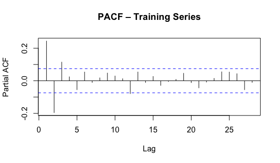

PACF of the training series. Significant spikes at lags 1, 2, and 3 suggest AR order 3, which fixes the filter order N = 3.

```r
pacf(dados$train, main = "PACF – Training Series")
```

An inspection of the PACF suggests that an AR model with $p = 3$ lags provides an adequate representation of the training series. This fixes $N = 3$ prior to cross-validation.

## Fitting the BTW-AR Model

```r
p <- 3

res <- btwar_fit(
  y_tr_raw = dados$train,
  y_te_raw = dados$test,
  fs       = fs,
  method   = "ls",
  N_vec    = p:p
)
cat("BTW-AR Performance:\n")
```

```
#> BTW-AR Performance:
```

```r
print(res$performance)
```

```
#> $rmse_train
#> [1] 1.013619
#>
#> $rmse_test
#> [1] 0.9561448
```

## Time-Series Predictions

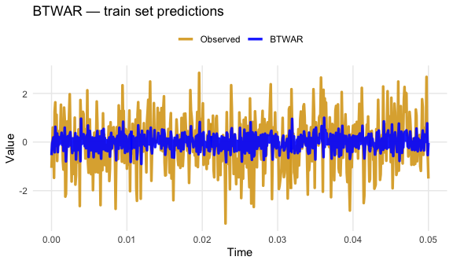

Training set: observed series vs. BTW-AR predictions.

```r
plot(res, dataset = "train", fs = fs,
     colour_observed = "goldenrod",
     colour_btwar    = "blue",
     lwd_observed    = 1.2,
     lwd_btwar       = 1.2)
```

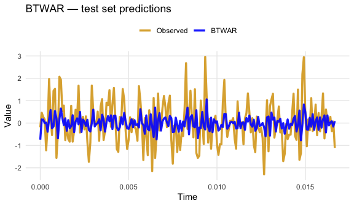

Test set: observed series vs. BTW-AR predictions.

```r
plot(res, dataset = "test", fs = fs,
     colour_observed = "goldenrod",
     colour_btwar    = "blue",
     lwd_observed    = 1.2,
     lwd_btwar       = 1.2)
```

## Spectral Interpretation: Bode Magnitude Diagram

A distinctive feature of the BTW-AR framework is that the fitted model admits a direct frequency-domain interpretation. The Bode magnitude diagram below shows the frequency response of the Butterworth prototype underlying the selected model.

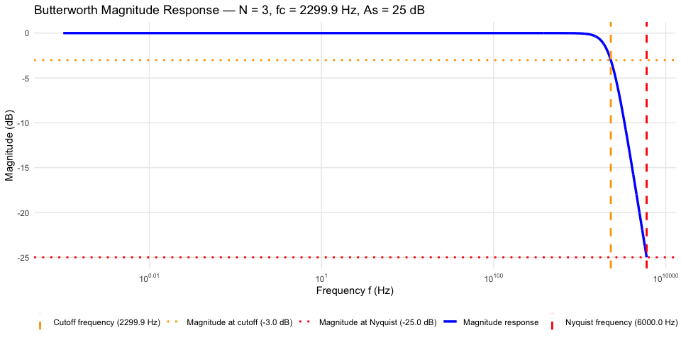

Butterworth magnitude response for the selected BTW-AR model.

```r
plot_bode(res, fs = fs)
```

The diagram reveals two distinct spectral regions:

- **Passband** $[0, f_c]$ — the model captures this band with a nearly flat gain, meaning that the low-frequency structure of the signal is represented with minimal distortion.
- **Transition band and stopband** $[f_c, f_{Nyquist}]$ — components in this region are progressively attenuated, reaching $A$ dB of suppression at the Nyquist frequency.

The cutoff frequency $f_c$ is therefore a direct, interpretable summary of the model: it marks the spectral boundary between the signal dynamics that the BTW-AR model captures and the higher-frequency variability that it treats as noise. This frequency-domain transparency is not available in conventional data-driven AR models, where the spectral implications of the estimated coefficients are implicit and not immediately readable.

## Z-Plane Pole Structure

The Z-plane pole plot compares the poles of the fitted BTW-AR model with those of the true data-generating process. Poles inside the unit circle correspond to stable models.

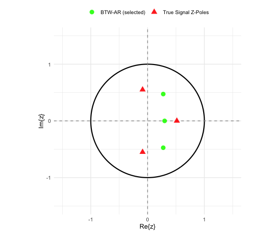

Z-plane poles: BTW-AR (selected) vs. true signal.

```r
df_true <- data.frame(
  Re = Re(sim_data$poles),
  Im = Im(sim_data$poles)
)

plot_zpoles(
  res,
  external_list = list(
    "True Signal Z-Poles" = df_true
  )
)
```

The pole locations of the BTW-AR model are entirely determined by the Butterworth design parameters $(N, A)$ and are not estimated from the data. Despite this structural constraint, the selected model places its poles in a region of the Z-plane consistent with the dominant dynamics of the true process, reflecting the effectiveness of the cross-validation procedure in identifying a spectrally appropriate model.

# Robustness Options

The `method` argument of `btwar_fit()` controls how the scaling parameter $\alpha$ is estimated from the data. Three options are available, corresponding to different assumptions about the residual distribution.

| Method | Loss function $\rho(e)$ | Recommended when |
| --- | --- | --- |
| `"ls"` | $e^2$ | Gaussian residuals |
| `"lad"` | $\|e\|$ | Heavy-tailed or skewed noise |
| `"huber"` | Quadratic-linear ($\delta = 1.345$) | Mild outliers present |

Note that the AR coefficient structure is identical across all three methods. Only the estimation of the scalar gain $\alpha$ changes. This means that the spectral interpretation provided by the Bode diagram remains valid regardless of the chosen method.

```r
fit_huber <- btwar_fit(
  y_tr_raw = dados$train,
  y_te_raw = dados$test,
  fs       = fs,
  method   = "huber",
  N_vec    = p:p
)
summary(fit_huber)
```

[output not shown]

# Conclusion

The BTW-AR framework provides a parsimonious and interpretable connection between classical filter design and autoregressive time-series modeling. By fixing the AR structure through Butterworth filter parameters and estimating only a scalar gain from the data, the method combines spectral interpretability with robust predictive performance.

# References

Bras-Geraldes, Carlos, J. Leonel Rocha, and Filipe Martins. 2026. “Butterworth-Induced Autoregressive Modeling Framework.” *Mathematics* 14 (3): 479. https://doi.org/10.3390/math14030479.